- ES218 Home
- [Moodle](https://moodle.colby.edu/course/view.php?id=8060)
- Data sets

# Week 3: Manipulating data tables with dplyr

This tutorial makes use of the following R package(s): **`dplyr`**

The data file *FAO_grains_NA.csv* will be used in this exercise. This dataset consists of grain yield and harvest year by north american country. The dataset was downloaded from http://faostat3.fao.org/ in June of 2014.

Run the following line to load the FAO data file into your current R session.

```r
dat <- read.csv("http://mgimond.github.io/ES218/Data/FAO_grains_NA.csv", header=TRUE)
```

# The `dplyr` basics

The basic set of R tools can accomplish many data table queries, but the syntax can be overwhelming and verbose. The package `dplyr` offers some nifty and simple querying functions as shown in the next subsections. `dplyr`’s data manipulation functions are summarized in the following table:

| `dplyr` function | Description |
| --- | --- |
| `filter()` | Subset by row values |
| `arrange()` | Sort rows by column values |
| `select()` | Subset columns |
| `mutate()` | Add columns |
| `summarise()` | Summarize columns |

Make sure to load the `dplyr` package before proceeding with the following examples.

```r
library(dplyr)
```

Tables can be subsetted by rows based on column values. For example, we may wish to grab all rows associated with `Oats`:

```r
dat.query1 <- filter(dat, Crop == "Oats")
summary(dat.query1)
```

```
                     Country              Crop                  Information       Year          Value
 Canada                  :104   Oats        :208   Area harvested (Ha):104   Min.   :1961   Min.   :  12667
 United States of America:104   Barley      :  0   Yield (Hg/Ha)      :104   1st Qu.:1974   1st Qu.:  20392
                                Buckwheat   :  0                             Median :1986   Median : 204821
                                Canary seed :  0                             Mean   :1986   Mean   :1350024
                                Grain, mixed:  0                             3rd Qu.:1999   3rd Qu.:1638250
                                Maize       :  0                             Max.   :2012   Max.   :9666550
                                (Other)     :  0
                                      Source
 Calculated data                         :104
 FAO data based on imputation methodology:  0
 FAO estimate                            :  0
 Official data                           :104
```

Note that R is case sensitive, so make sure that you respect each letter’s case (i.e. upper or lower).

We can expand our query by including both `Oats`, `Buckwheat` and limiting the country to `Canada`.

```r
dat.query2 <- filter(dat, Crop == "Oats" | Crop == "Buckwheat",
                          Country == "Canada")
summary(dat.query2)
```

```
                     Country              Crop                  Information       Year          Value
 Canada                  :200   Oats        :104   Area harvested (Ha):101   Min.   :1961   Min.   :      0
 United States of America:  0   Buckwheat   : 96   Yield (Hg/Ha)      : 99   1st Qu.:1973   1st Qu.:  11822
                                Barley      :  0                             Median :1986   Median :  22197
                                Canary seed :  0                             Mean   :1986   Mean   : 504098
                                Grain, mixed:  0                             3rd Qu.:1998   3rd Qu.: 924675
                                Maize       :  0                             Max.   :2012   Max.   :4277000
                                (Other)     :  0
                                      Source
 Calculated data                         :99
 FAO data based on imputation methodology: 0
 FAO estimate                            : 2
 Official data                           :99
```

The character `|` is the Boolean operator OR. So in our example, the query can be read as “… crop equals oats OR crop equals buckwheat”. Had we used the AND operator, `&`, instead as in `Crop == "Oats" & Crop == "Buckwheat"` the output would have returned zero rows since a `Crop` value cannot be both `Oats` AND `Buckwheat`.

We can expand this query by limiting our output to the years 2005 to 2010

```r
library(dplyr)
dat.query3 <- filter(dat, Crop == "Oats" | Crop == "Buckwheat",
                          Country == "Canada",
                          Year >= 2005 & Year <= 2010)
summary(dat.query3)
```

```
                     Country             Crop                 Information      Year          Value
 Canada                  :18   Oats        :12   Area harvested (Ha):9    Min.   :2005   Min.   :   2000
 United States of America: 0   Buckwheat   : 6   Yield (Hg/Ha)      :9    1st Qu.:2006   1st Qu.:  11500
                               Barley      : 0                            Median :2007   Median :  26615
                               Canary seed : 0                            Mean   :2007   Mean   : 453810
                               Grain, mixed: 0                            3rd Qu.:2008   3rd Qu.: 961825
                               Maize       : 0                            Max.   :2010   Max.   :1815700
                               (Other)     : 0
                                      Source
 Calculated data                         :9
 FAO data based on imputation methodology:0
 FAO estimate                            :0
 Official data                           :9
```

Note the use of the AND Boolean operator (`&`) instead of the OR operator (`|`) for the `Year` query. We want the `Year` value to satisfy two criteria simultaneously: *greater than or equal to 2005* **AND** *less than or equal to 2010*. Had we used the `|` operator, R would have returned all years since all year values satisfy at least one of the two criteria.

## Sort rows by column value: `arrange`

You can sort a table based on a column’s values. For example, to sort `dat` by crop name type:

```r
dat.sort1 <- arrange(dat, Crop)
head(dat.sort1)
```

```
                   Country   Crop         Information Year      Value          Source
1                   Canada Barley Area harvested (Ha) 2012 2060000.00   Official data
2                   Canada Barley       Yield (Hg/Ha) 2012   38894.66 Calculated data
3 United States of America Barley Area harvested (Ha) 2012 1312810.00   Official data
4 United States of America Barley       Yield (Hg/Ha) 2012   36533.24 Calculated data
5                   Canada Barley Area harvested (Ha) 2011 2364800.00   Official data
6                   Canada Barley       Yield (Hg/Ha) 2011   32796.43 Calculated data
```

```r
tail(dat.sort1)
```

```
     Country      Crop         Information Year    Value                                   Source
1496  Canada Triticale Area harvested (Ha) 1991  1093.00                            Official data
1497  Canada Triticale       Yield (Hg/Ha) 1991 21957.91                          Calculated data
1498  Canada Triticale Area harvested (Ha) 1990  1074.00 FAO data based on imputation methodology
1499  Canada Triticale       Yield (Hg/Ha) 1990 26396.65                          Calculated data
1500  Canada Triticale Area harvested (Ha) 1989  1093.00                             FAO estimate
1501  Canada Triticale       Yield (Hg/Ha) 1989 21957.91                          Calculated data
```

By default, `arrange` sorts by ascending order. To sort by descending order, wrap the column name with the function `desc()`. For example, to sort the table by `Crop` in ascending order then by `Year` in descending order, type:

```r
dat.sort2 <- arrange(dat, Crop, desc(Year))
head(dat.sort2)
```

```
                   Country   Crop         Information Year      Value          Source
1                   Canada Barley Area harvested (Ha) 2012 2060000.00   Official data
2                   Canada Barley       Yield (Hg/Ha) 2012   38894.66 Calculated data
3 United States of America Barley Area harvested (Ha) 2012 1312810.00   Official data
4 United States of America Barley       Yield (Hg/Ha) 2012   36533.24 Calculated data
5                   Canada Barley Area harvested (Ha) 2011 2364800.00   Official data
6                   Canada Barley       Yield (Hg/Ha) 2011   32796.43 Calculated data
```

```r
tail(dat.sort2)
```

```
     Country      Crop         Information Year    Value                                   Source
1496  Canada Triticale Area harvested (Ha) 1991  1093.00                            Official data
1497  Canada Triticale       Yield (Hg/Ha) 1991 21957.91                          Calculated data
1498  Canada Triticale Area harvested (Ha) 1990  1074.00 FAO data based on imputation methodology
1499  Canada Triticale       Yield (Hg/Ha) 1990 26396.65                          Calculated data
1500  Canada Triticale Area harvested (Ha) 1989  1093.00                             FAO estimate
1501  Canada Triticale       Yield (Hg/Ha) 1989 21957.91                          Calculated data
```

## Subset by column: `select`

You can grab a subset of the table by column(s). To extract the columns `Crop`, `Year` and `Value`, type:

```r
dat.subcol <- select(dat, Crop, Year, Value)
head(dat.subcol)
```

```
          Crop Year      Value
1       Barley 2012 2060000.00
2       Barley 2012   38894.66
3    Buckwheat 2012       0.00
4  Canary seed 2012  101900.00
5  Canary seed 2012   12161.92
6 Grain, mixed 2012   57900.00
```

## Adding columns: `mutate`

You can add columns (and compute their values) using the `mutate` function. For example, to add a column `Ctr_abbr` and assign it the abbreviated values `CAN` for Canada and `USA` for the United States of America based on the values in column `Country` type:

```r
dat.extended <- mutate(dat, Ctr_abbr = ifelse(Country == "Canada", "CAN", "USA"))
head(dat.extended)
```

```
  Country         Crop         Information Year      Value          Source Ctr_abbr
1  Canada       Barley Area harvested (Ha) 2012 2060000.00   Official data      CAN
2  Canada       Barley       Yield (Hg/Ha) 2012   38894.66 Calculated data      CAN
3  Canada    Buckwheat Area harvested (Ha) 2012       0.00    FAO estimate      CAN
4  Canada  Canary seed Area harvested (Ha) 2012  101900.00   Official data      CAN
5  Canada  Canary seed       Yield (Hg/Ha) 2012   12161.92 Calculated data      CAN
6  Canada Grain, mixed Area harvested (Ha) 2012   57900.00   Official data      CAN
```

```r
tail(dat.extended)
```

```
                      Country    Crop         Information Year      Value          Source Ctr_abbr
1496 United States of America Popcorn Area harvested (Ha) 1961   83162.00   Official data      USA
1497 United States of America Popcorn       Yield (Hg/Ha) 1961   21762.34 Calculated data      USA
1498 United States of America     Rye Area harvested (Ha) 1961  624000.00   Official data      USA
1499 United States of America     Rye       Yield (Hg/Ha) 1961   11121.79 Calculated data      USA
1500 United States of America Sorghum Area harvested (Ha) 1961 4445000.00   Official data      USA
1501 United States of America Sorghum       Yield (Hg/Ha) 1961   27442.07 Calculated data      USA
```

Here, we make use of an embedded function, `ifelse`, which performs a conditional operation: if the `Country` value is `Canada` return `CAN` if not, return `USA`.

Note that if you wish to *rename* a column, you can use the `rename()` function instead of `mutate`.

## Summarize columns: `summarise`

You can summarize (or “collapse”) one or more columns using the `summarise` function. For instance, to get the minimum and maximum years from the `Year` column, type:

```r
summarise(dat, yr_min = min(Year), yr_max=max(Year))
```

```
  yr_min yr_max
1   1961   2012
```

## Splitting data operations by group: `group_by`

The `group_by` function will split any operations applied to the dataframe into groups defined by one or more columns. For example, if we wanted to get the minimum and maximum years from the `Year` column for which crop data are available *by crop type*, we would type the following:

```r
dat.grp <- group_by(dat, Crop)
summarise(dat.grp, yr_min = min(Year), yr_max=max(Year))
```

```
Source: local data frame [11 x 3]

           Crop yr_min yr_max
         (fctr)  (int)  (int)
1        Barley   1961   2012
2     Buckwheat   1961   2012
3   Canary seed   1980   2012
4  Grain, mixed   1961   2012
5         Maize   1961   2012
6        Millet   1961   2012
7          Oats   1961   2012
8       Popcorn   1961   1982
9           Rye   1961   2012
10      Sorghum   1961   2012
11    Triticale   1989   2012
```

The `dat.grp` object is a special data structure which differs from that of `dat` in that it explicitly defines the groups for which any subsequent operations (like `summarise`) are to be split across.

## `dplyr`’s output data structure

Many of `dplyr`’s functions will add one or more classes to a data table. For example, if we stored the summary output from the last chunk of code to an object called `dat.sum`, we’d discover that this object is associated with three classes.

```r
dat.sum <- summarise(dat.grp, yr_min = min(Year), yr_max=max(Year))
class(dat.sum)
```

```
[1] "tbl_df"     "tbl"        "data.frame"
```

This may prove to be problematic when using this table in none `dplyr` functions. To remedy this, you can force the `dat.sum` object to a standalone `dataframe` as follows:

```r
dat.df <- data.frame(dat.sum)
class(dat.df)
```

```
[1] "data.frame"
```

# Combining table manipulation functions using `%>%`

```r
dat.yield <- filter(dat, Information == "Yield (Hg/Ha)", Crop == "Oats")
dat.grp   <- group_by(dat.yield, Country)
dat.sum   <- summarise(dat.grp, mean_yield = mean(Value))
data.frame(dat.sum)
```

```
                   Country mean_yield
1                   Canada   21932.51
2 United States of America   19785.44
```

The one downside to this approach of combining data table manipulation functions for complex queries is the use of several intermediate objects (e.g. `dat.yield`, `dat.grp`, `dat.sum`). This can make the workflow difficult to follow and clutter your R session with needless intermediate objects.

Another approach to combining `dplyr` operations is to use the **piping operator** ,`%>%`, which daisy chains `dplyr` operations. So our previous workflow would look like:

```r
dat %>%
  filter(Information == "Yield (Hg/Ha)", Crop == "Oats") %>%
  group_by(Country) %>%
  summarise(mean_yield = mean(Value)) %>%
  data.frame()
```

```
                   Country mean_yield
1                   Canada   21932.51
2 United States of America   19785.44
```

The chunk of code can be read as *“… with the `dat` table, `filter` by …, then `group_by` …., then `summarise` by …”* with the result from one operation being passed on to the next using the `%>%` operator. Note that the `filter`, `group_by` and `summarise` functions do not include the data table name making the chunk of code less cluttered and easier to read.

This chunk of code will output the results to the screen, if you want to save it to an object called `dat2`, replace the first line with `dat2 <- dat %>% ...`.

Here’s a more complicated output whereby the median yield for each USA crop is summarized by year for the years spanning 2005 through 2010 and the output is sorted by crop name (in ascending order) and median yield value (in descending order).

```r
dat %>%
  filter(Information == "Yield (Hg/Ha)", Year >= 2005, Year <=2010,
         Country=="United States of America") %>%
  group_by(Crop, Year) %>%
  summarise(median_yield = round(median(Value))) %>%
  arrange(Crop, desc(median_yield))
```

```
Source: local data frame [42 x 3]
Groups: Crop [7]

        Crop  Year median_yield
      (fctr) (int)        (dbl)
1     Barley  2010        39345
2     Barley  2009        39287
3     Barley  2005        34873
4     Barley  2008        34195
5     Barley  2006        32846
6     Barley  2007        32278
7  Buckwheat  2005        11019
8  Buckwheat  2009        10931
9  Buckwheat  2010        10555
10 Buckwheat  2006        10000
..       ...   ...          ...
```

# More on the `group_by` function

The `group_by` function followed by the `summarise` function will generate a new table with as many rows as there are groups defined in the `group_by` function. But grouping variables can be used for other purposes where the output table contains the same number of rows as the input table. The following sub-sections highlight a few examples.

## Normalizing each value in a group by the group median

In this example, we are subtracting each value in a group by that group’s median. This can be useful in identifying which year yields are higher than or lower than the median yield value within each crop group. We will concern ourselves with US yields only and sort the output by crop type. We’ll save the output dataframe as `dat2`.

```r
dat2 <- dat %>%
  filter(Information == "Yield (Hg/Ha)",
         Country == "United States of America") %>%
  select(Crop, Year, Value)                     %>%
  group_by(Crop)                                %>%
  mutate(NormYield = Value - median(Value))     %>%
  arrange(Crop)
```

Let’s plot the normalized yields by year for Barley and add a `0` line representing the (normalized) central value.

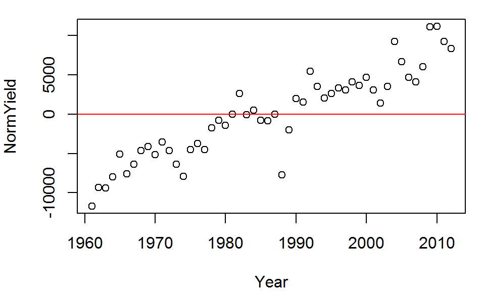

```r
plot( NormYield ~ Year, dat2[dat2$Crop == "Barley",] )
abline(h = 0, col="red")
```

The relative distribution of points does not change, but the values do (they are re-scaled) allowing us to compare values based on some localized (group) context. This technique will prove very useful later on in the course when EDA topics are explored.

## Computing the residuals after fitting a linear regression model for each group

(Note that this example covers topics best suited for advanced users)

This is an extension of the last example where, instead of fitting a constant (median) value to the yield values within each crop group, we fit a linear regression line to crop yield vs. year within each crop group, then compute the differences between the line and the values thus giving us the *residuals*.

```r
dat2 <- dat %>%
  filter(Information == "Yield (Hg/Ha)",
         Country =="United States of America") %>%
  select(Crop, Year, Value)                    %>%
  group_by(Crop)                               %>%
  mutate(Residuals = Value - predict(lm(deparse(substitute(Value ~ Year))),
                                     data.frame(Year)) )
```

The `deparse(substitute(...))` functions are necessary in the piping operations for `dplyr` to properly interpret the formula. The `predict()` function extracts predicted values from the regression model by passing one or many values as a dataframe (even if we are only predicting the crop yield for a single year by row).

Manny Gimond (2016)